# Homework_basic_visual

Ivan Derkachev

2024-09-27

## Data reading

```r
hogwarts <- read.csv("data/hogwarts_2024.csv")
```

### Transform of variables

```r
hogwarts <- hogwarts %>% mutate(
  across(c(id, sex, house, course, bloodStatus), ~ as.factor(.x)))
```

## Data visualisation

### Столбчатые диаграммы

#### Задание 1

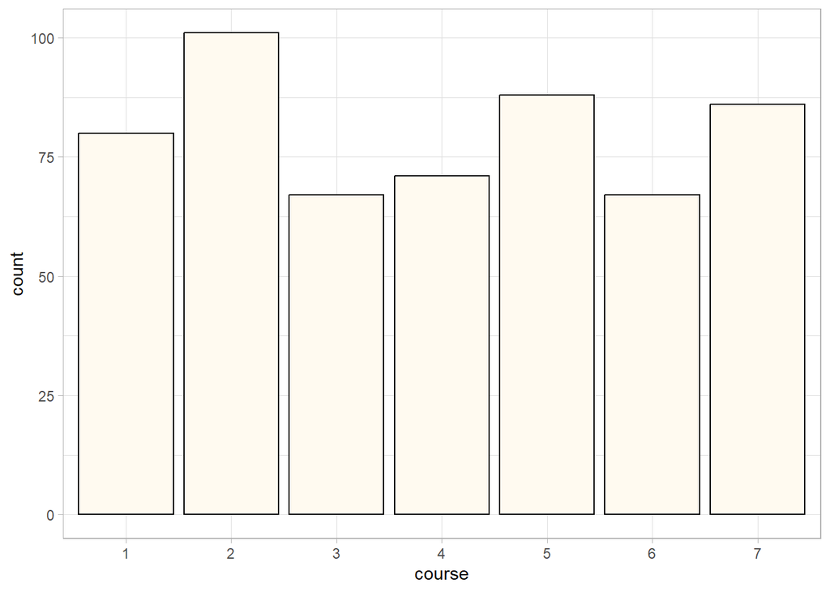

```r
ggplot(hogwarts) +
  geom_bar(aes(x = course),
           colour = "black",
           fill = "#FFFAF0") +
  theme_light()
```

#### Задание 2

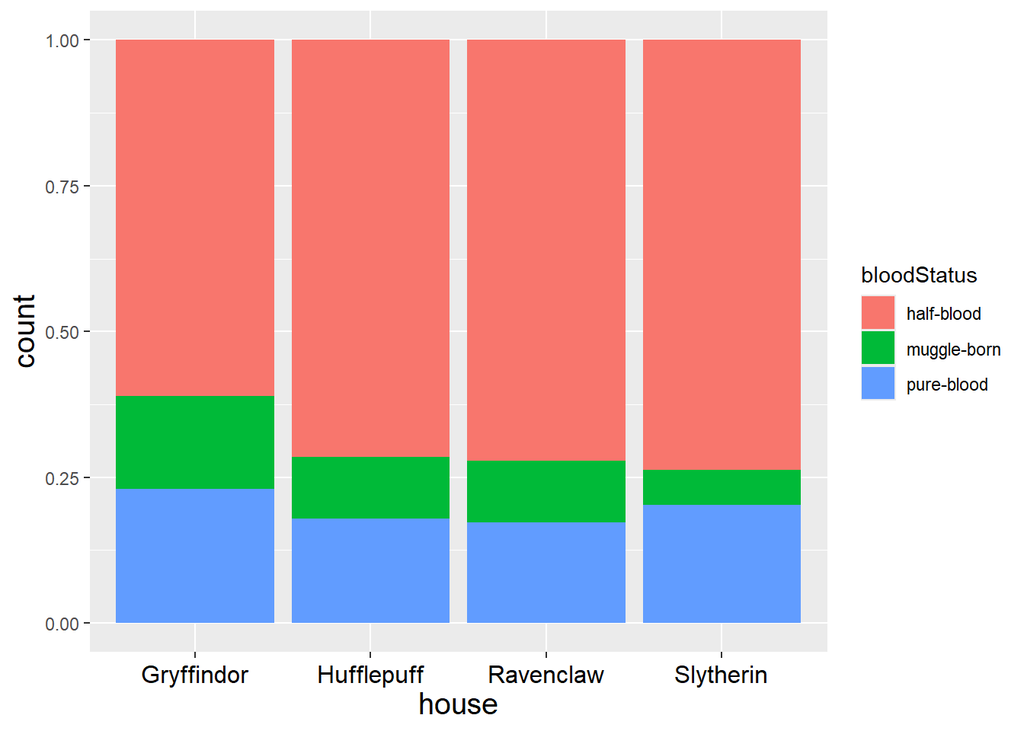

```r
my_custom_theme <- theme(
  axis.title = element_text(size = 15),
  axis.text.x = element_text(size = 12,
                             colour = "black",
                             vjust = 0.6))

ggplot(hogwarts) +
  geom_bar(aes(x = house,
               fill = bloodStatus),
           position = "fill") +
  my_custom_theme
```

Более половины учащихся на каждом факультете - “полукровки”. Маглы составляют наименьший процент среди учащихся по каждому факультету. Доля чистокровок менее 25% независимо от факультета.

#### Задание 3

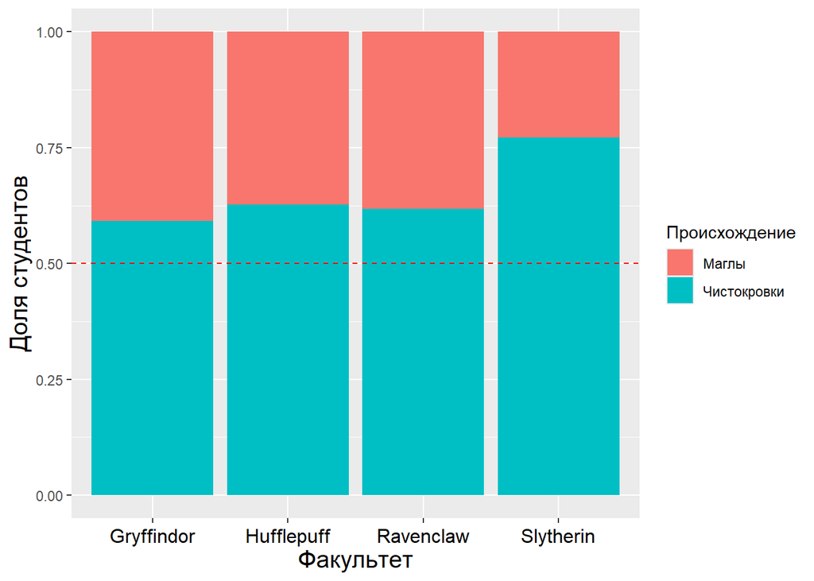

```r
hogwarts %>%
  filter(bloodStatus %in% c("muggle-born", "pure-blood")) %>%
  ggplot() +
  geom_bar(aes(x = house,
               fill = bloodStatus),
           position = "fill") +
  geom_hline(yintercept = 0.5,
             colour = "red",
             linetype = "dashed") +
  my_custom_theme +
  labs(x = "Факультет",
       y = "Доля студентов") +
  scale_fill_discrete(
    name = "Происхождение",
    labels = c("Маглы", "Чистокровки"))
```

### Боксплоты

#### Задание 1

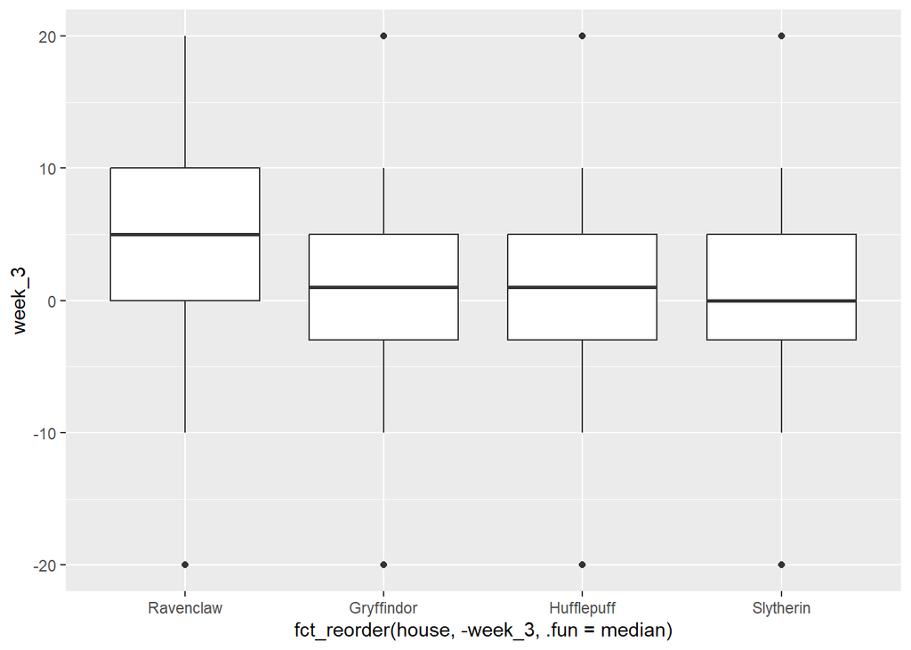

```r
ggplot(hogwarts, aes(x = fct_reorder(house, -week_3, .fun = median),
                     y = week_3)) +
  geom_boxplot()
```

#### Задание 2

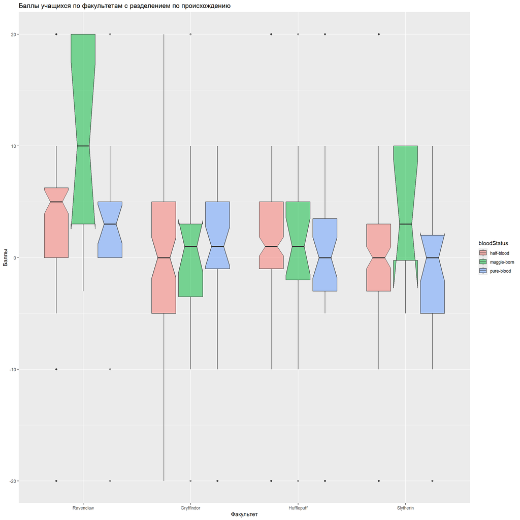

```r
ggplot(hogwarts, aes(x = fct_reorder(house, -week_3, .fun = median),
                     y = week_3,
                     fill = bloodStatus)) +
  geom_boxplot(notch = TRUE, alpha = 0.5) +
  labs(title = "Баллы учащихся по факультетам с разделением по происхождению",
       x = "Факультет", y = "Баллы")
```

#### Задание 3

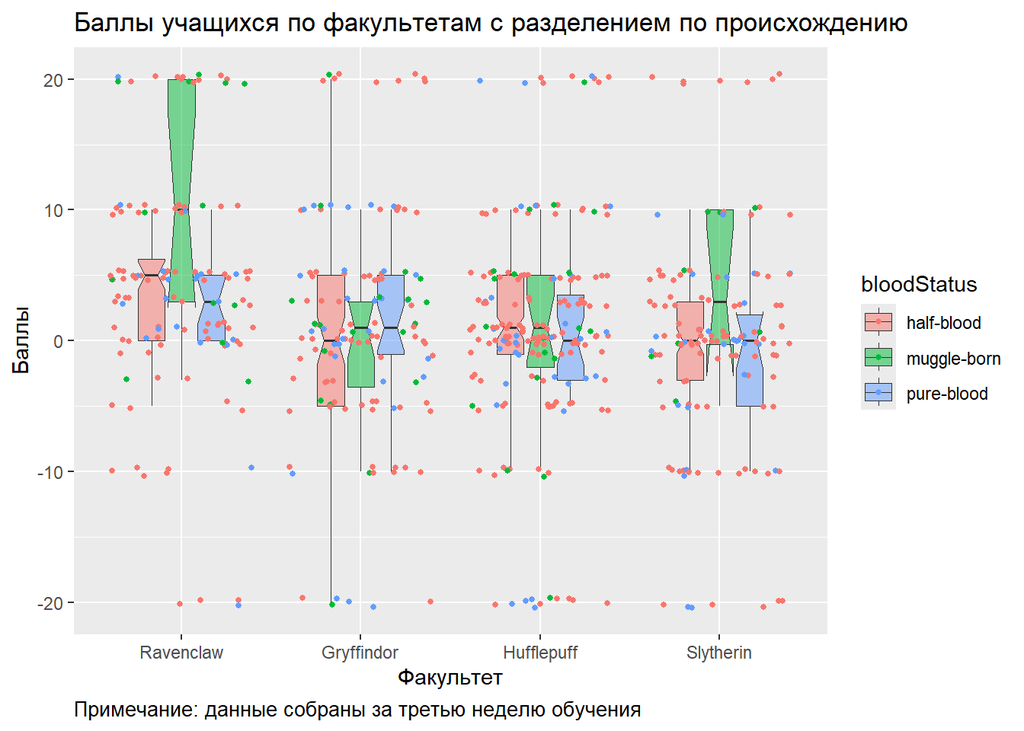

```r
ggplot(hogwarts, aes(x = fct_reorder(house, -week_3, .fun = median),
                     y = week_3,
                     fill = bloodStatus)) +
  geom_boxplot(notch = TRUE,
               outlier.shape = NA,
               alpha = 0.5,
               size = 0.3,
               width = 0.5) +
  labs(title = "Баллы учащихся по факультетам с разделением по происхождению",
       x = "Факультет", y = "Баллы",
       caption = "Примечание: данные собраны за третью неделю обучения") +
  theme(plot.caption = element_text(hjust = 0, vjust = 1, size = 10)) +
  geom_jitter(aes(colour = bloodStatus), size = 1)
```

### Разное

#### Задание 1

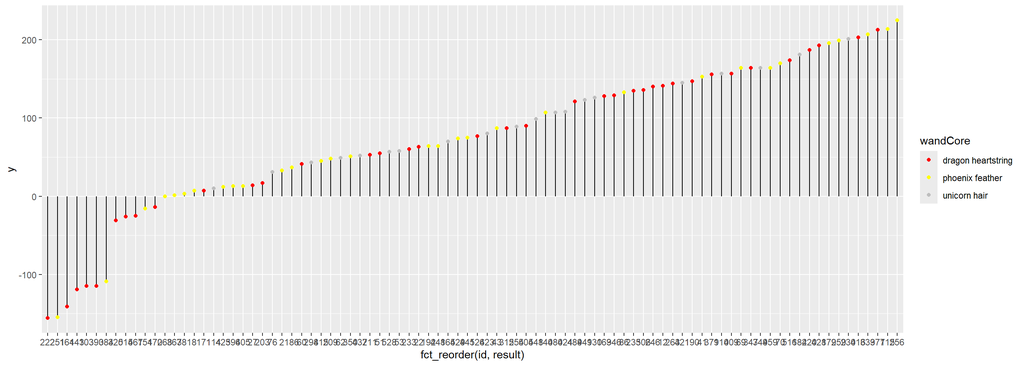

```r
hogwarts %>% filter(course == 5) %>%
  ggplot() +
  geom_segment(aes(x = fct_reorder(id, result),
                   xend = fct_reorder(id, result),
                   y = 0,
                   yend = result)) +
  geom_point(aes(x = fct_reorder(id, result),
                 y = result,
                 colour = wandCore)) +
  scale_colour_manual(values = c("unicorn hair" = "grey",
                                 "phoenix feather" = "yellow",
                                 "dragon heartstring" = "red"))
```

#### Задание 2

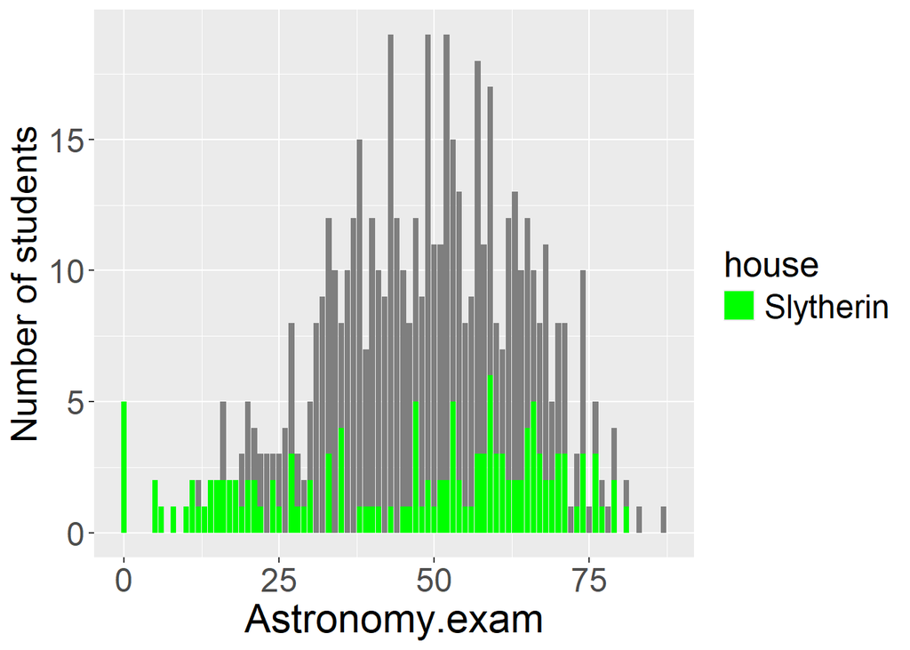

```r
ggplot(hogwarts) +
  geom_bar(aes(x = Astronomy.exam, fill = house)) +
  scale_fill_manual(values = c("Slytherin" = "green")) +
  theme(axis.text.x = element_text(size = 18),
        axis.text.y = element_text(size = 18),
        axis.title.x = element_text(size = 22),
        axis.title.y = element_text(size = 20),
        legend.text = element_text(size = 18),
        legend.title = element_text(size = 20)) +
  labs(y = "Number of students")
```

#### Задание 3

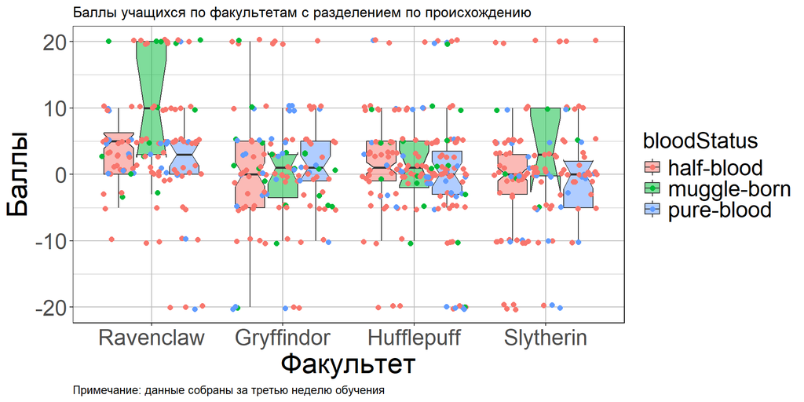

```r
theme_custom <- theme(
  axis.text = element_text(size = 20),
  axis.title = element_text(size = 25),
  legend.title = element_text(size = 20),
  legend.text = element_text(size = 20),
  panel.background = element_rect(fill = "white"),
  panel.grid = element_line(colour = "grey"),
  panel.border = element_rect(colour = "black", fill = NA))


ggplot(hogwarts, aes(x = fct_reorder(house, -week_3, .fun = median),
                     y = week_3,
                     fill = bloodStatus)) +
  geom_boxplot(notch = TRUE,
               outlier.shape = NA,
               alpha = 0.5) +
  labs(title = "Баллы учащихся по факультетам с разделением по происхождению",
       x = "Факультет",
       y = "Баллы",
       caption = "Примечание: данные собраны за третью неделю обучения") +
  theme(plot.caption = element_text(hjust = 0, vjust = 1, size = 10)) +
  geom_jitter(aes(colour = bloodStatus), size = 2) +
  theme_custom
```

### Фасетирование

#### Задание 1

1. Гистограммы лучше фасетировать по столбцам.

Гистограммы показывают распределение данных по одной оси (часто ось x), и ключевая информация содержится в форме распределения. Когда гистограммы расположены по столбцам, форма распределений легче воспринимается, так как не нужно перемещать взгляд вверх-вниз, а только влево-вправо, что естественнее для чтения. Фасетирование по столбцам позволяет сравнивать распределения вдоль горизонтальной оси, что воспринимается проще.

Однако фасетирование по строкам иногда может быть полезно. Например, если количество фасеток небольшое и акцент должен быть на высоте гистограмм (частотах).

2. Violin plot’ы лучше фасетировать по строкам.

Violin plot включает информацию о плотности распределения, которая ориентирована вертикально. Чтобы лучше воспринимать различия в плотности и симметрии распределений, логично располагать графики вертикально. Это сделает сравнение форм более удобным.

3. Общее правило: Для графиков, где ключевая информация представлена по оси x (например, гистограммы), лучше использовать фасетирование по столбцам. Для графиков, где важна информация по оси y (например, violin plots), лучше использовать фасетирование по строкам, чтобы легче было сравнивать распределения вдоль вертикальной оси.

#### Задание 2

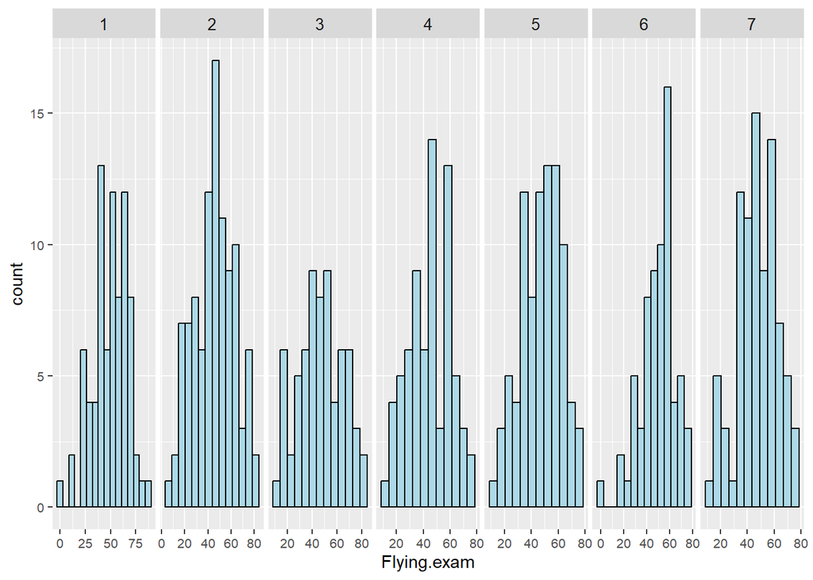

```r
# Применим правило Фридмана-Дьякониса для определения числа столбцов гистограммы
ggplot(hogwarts, aes(x = Flying.exam)) +
  geom_histogram(fill = "lightblue",
                 colour = "black",
                 binwidth = 2 * IQR(hogwarts$Flying.exam)/
                   length(hogwarts$Flying.exam)^(1/3)) +
  facet_grid(.~course, scales = "free_x", space = "free_y") +
  theme(axis.text.x = element_text(size = 8),
        axis.text.y = element_text(size = 8),
        strip.text = element_text(size = 10),
        panel.spacing = unit(0.2, "lines"))
```

#### Задание 3

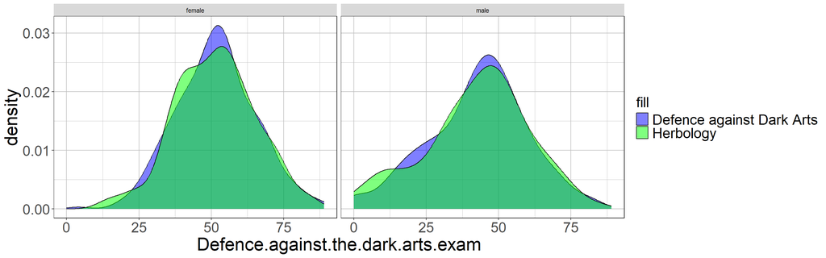

```r
ggplot(hogwarts) +
  geom_density(aes(x = Defence.against.the.dark.arts.exam,
                   fill = "Defence against Dark Arts"),
               alpha = 0.5) +
  geom_density(aes(x = Herbology.exam,
                   fill = "Herbology"),
               alpha = 0.5) +
  scale_fill_manual(values = c("Defence against Dark Arts" = "blue",
                               "Herbology" = "green")) +
  theme_custom +
  facet_wrap(~sex)
```